# GSS challange

Christina Jones!

7 Oct 2021

# Introduction

Is attitude toward capitol punishment (CAPPUN) independent of race (RACE)? If not, then whose view differs from whom??

$H_0$ The attitude towards capitol punishment is independent of race.  
$H_1$ The attitude towards capitol punishment is dependence on race

# Methods

The data in this study is attitude towards capitol punishment and the race of the individual. The variable that are used in this study are considered categorical.

# Results

## Descriptive Results

### Graphical Descriptive Results

```r
dd2 <- GSS %>% group_by(RACE,CAPPUN) %>% summarize(count=n()) %>% mutate(prcnt=count/sum(count))
```

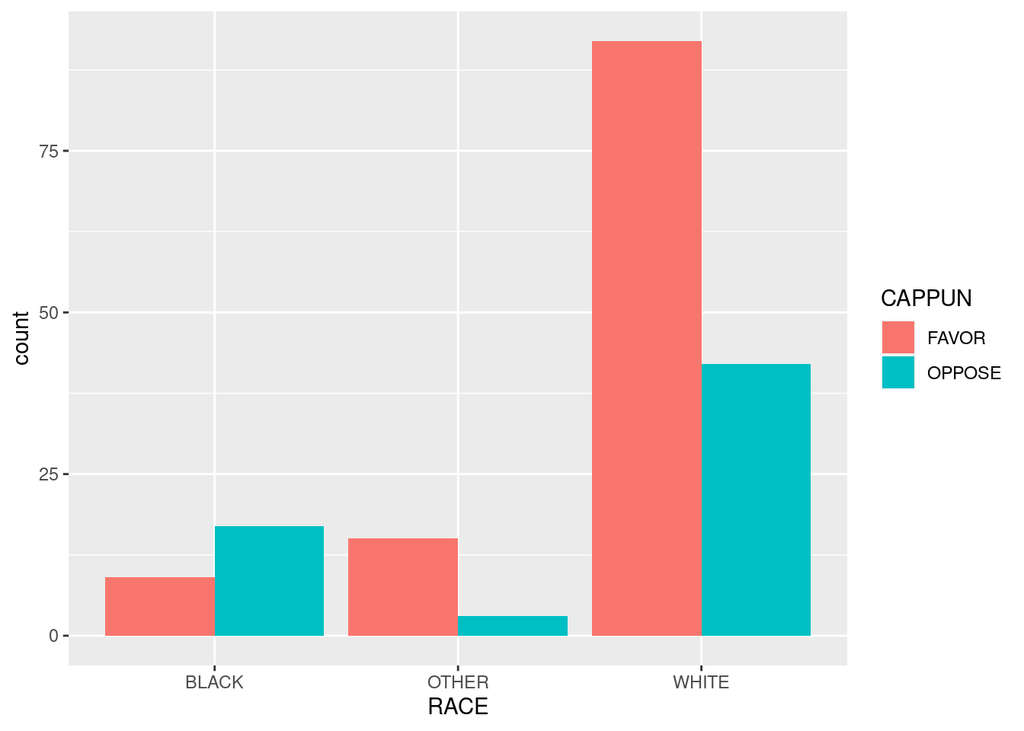

```r
# the group_by followed by summarize(count=n())

basicC <- ggplot(dd2,aes(x=RACE,y=count,fill=CAPPUN))
basicC + geom_bar(stat="identity",position="dodge")
```

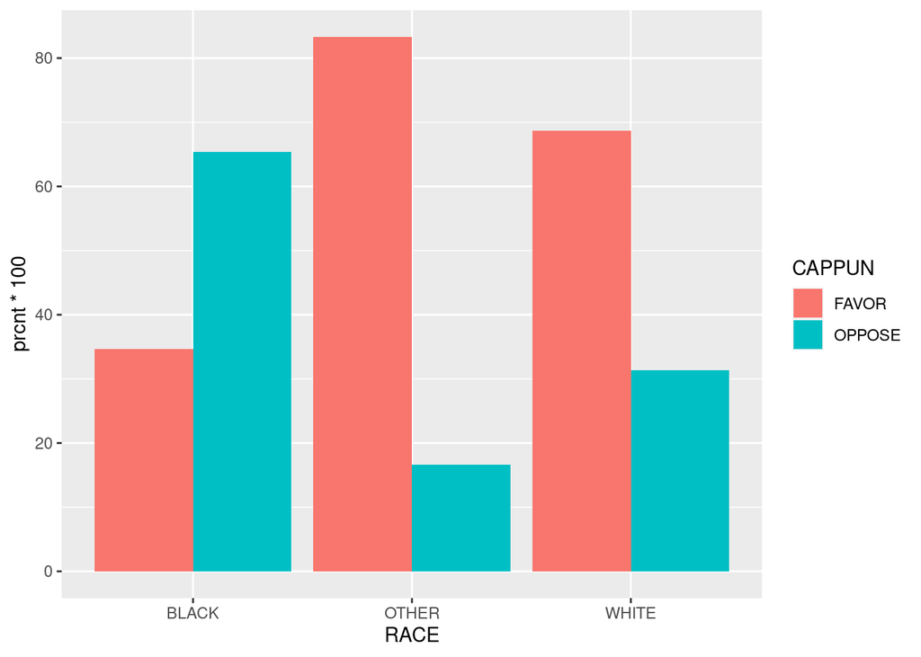

```r
#Now for percentage plot

basicCC <- ggplot(dd2,aes(x=RACE,y=prcnt*100,fill=CAPPUN))
basicCC + geom_bar(stat="identity", position = "dodge")
```

This graph shows that white and other races favor capitol punishment while blacks opposes.

### Numerical Descriptive Results

```r
table1 <- xtabs(~RACE + CAPPUN, data=GSS)
rowPerc(table1)
```

```
##        CAPPUN
## RACE     FAVOR OPPOSE  Total
##   BLACK  34.62  65.38 100.00
##   OTHER  83.33  16.67 100.00
##   WHITE  68.66  31.34 100.00
```

```r
colPerc(table1)
```

```
##        CAPPUN
## RACE     FAVOR OPPOSE
##   BLACK   7.76  27.42
##   OTHER  12.93   4.84
##   WHITE  79.31  67.74
##   Total 100.00 100.00
```

35% of blacks favor capitol punishment. More the 65% of whites and other races favor capitol punishment. More then 65% of blacks oppose capitol punishment It appears that there is a correlation between capitol punishment and race.

## Inferential Results

```r
fisherXY = function(x, y, confL = 0, printAll=FALSE){
  # Inputs:
  #   x: factor variable, 2 levels
  #   y: factor variable, n levels
  # confL: confidence level, default = 0.95
  #        print only those tables, results if p-value < (1-confL)
  # printAll: overide the 'print only if p-value < (1-confL), and
  #           print all tables and fisher test results
  #
  # Constraint:
  #   x and y must be same length
  #
  # Outputs:
  #   All 2x2 Fisher exact tests

  if(confL<0 || confL> 1){
    print('error: confL must be between 0 and 1')
    return(999)
  }

  if(!is.factor(x)) x=as.factor(x)
  if(!is.factor(y)) y=as.factor(y)

  fisherTable = as.matrix(table(x, y))
  cat('\ncontingency table:\n')
  print(fisherTable)
  cat('\n***All 2X2 tests****\n\n')

  # all 2x2 tests
  levelsY = levels(y)
  levelsX = levels(x)

  m = length(levelsX)
  n = length(levelsY)

  confLevel = 0.95
  if (confL !=0 ) confLevel=confL

  for (i in 1:(m-1))
       for(j in ((i+1):m))
          for (k in 1:(n-1))
             for (l in ((k+1):n)) {

                 fisherIndexX = c(i,j)
                 fisherIndexY = c(k,l)

                 fTempTable = as.matrix(fisherTable[fisherIndexX,
                                        fisherIndexY])

                 fisherTest=fisher.test(fTempTable, conf.int = TRUE,
                              conf.level = confLevel)

                 if((fisherTest$p.value < (1-confLevel) ) || printAll){

                       print(c(levelsX[i], levelsX[j]))
                       print(c(levelsY[k], levelsY[l]))
                       print(fTempTable)
                       print(fisherTest)
                       cat('\n')
                 }

        }
}
```

```r
fisherXY(GSS$RACE,GSS$CAPPUN,printAll = T)
```

```
##
## contingency table:
##        y
## x       FAVOR OPPOSE
##   BLACK     9     17
##   OTHER    15      3
##   WHITE    92     42
##
## ***All 2X2 tests****
##
## [1] "BLACK" "OTHER"
## [1] "FAVOR"  "OPPOSE"
##        y
## x       FAVOR OPPOSE
##   BLACK     9     17
##   OTHER    15      3
##
##  Fisher's Exact Test for Count Data
##
## data:  fTempTable
## p-value = 0.002022
## alternative hypothesis: true odds ratio is not equal to 1
## 95 percent confidence interval:
##  0.01640516 0.54145577
## sample estimates:
## odds ratio
##  0.1121865
##
##
## [1] "BLACK" "WHITE"
## [1] "FAVOR"  "OPPOSE"
##        y
## x       FAVOR OPPOSE
##   BLACK     9     17
##   WHITE    92     42
##
##  Fisher's Exact Test for Count Data
##
## data:  fTempTable
## p-value = 0.001598
```

[output cut: 10 more lines]

```
##        y
## x       FAVOR OPPOSE
##   OTHER    15      3
##   WHITE    92     42
##
##  Fisher's Exact Test for Count Data
##
## data:  fTempTable
## p-value = 0.2751
## alternative hypothesis: true odds ratio is not equal to 1
## 95 percent confidence interval:
##   0.5963258 12.8936216
## sample estimates:
## odds ratio
##   2.271951
```

This data shows that between white and other races these is not much of a difference with a P value of 0.27. There is an extreme difference between white and blacks with a P value of 0.0016. There is also an extreme difference between blacks and other races with a P value of 0.002022.

# Discussion and Conclusion

The data shows that there is an extreme difference with the attitude toward capitol punishment and races, however the difference is not evident with all races. Whites and others races are close in the percentage of being for capitol punishment while black attitude toward capitol punishment is a less percentage then both. In conclusion due to the fact the percentages and number do not correlate, We reject the Null Hypothesis.